# Mineros BN

First let us create the BN structure that we will be using

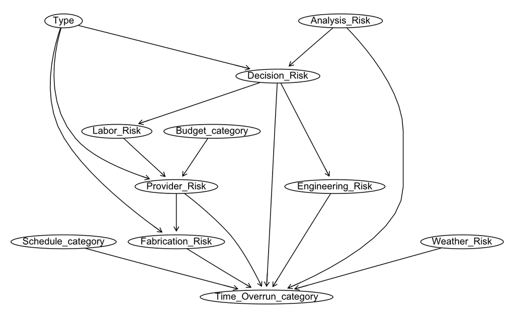

```r
library(bnlearn)
library(Rgraphviz)


create_model = empty.graph(c("Schedule_category", "Time_Overrun_category",
                             "Budget_category", "Type",
                             "Fabrication_Risk", "Weather_Risk",
                             "Provider_Risk", "Engineering_Risk", "Decision_Risk",
                             "Analysis_Risk", "Labor_Risk"))

arc.set = matrix(c(
                   "Type", "Fabrication_Risk",
                   "Type", "Provider_Risk",
                   "Type", "Decision_Risk",
                   "Analysis_Risk", "Decision_Risk",
                   "Decision_Risk", "Labor_Risk",
                   "Decision_Risk", "Engineering_Risk",
                   "Budget_category", "Provider_Risk",
                   "Labor_Risk", "Provider_Risk",
                   "Provider_Risk", "Fabrication_Risk",
                   "Schedule_category", "Time_Overrun_category",
                   "Engineering_Risk", "Time_Overrun_category",
                   "Fabrication_Risk", "Time_Overrun_category",
                   "Weather_Risk", "Time_Overrun_category",
                   "Decision_Risk", "Time_Overrun_category",
                   "Provider_Risk", "Time_Overrun_category",
                   "Analysis_Risk", "Time_Overrun_category"
),
ncol = 2, byrow = TRUE,
dimnames = list(NULL, c("from", "to")))

arcs(create_model) = arc.set
graphviz.plot(create_model, shape = "ellipse")
```

Then we can load the real data, learn the BN parameters from it and cross-validate the prediction power for the Overrun node using the discretized variables by the hartemink method.

```r
library(dplyr)
initial_data <- read.csv("/Users/camilodavid/Library/CloudStorage/OneDrive-Personal/Tohoku U/PhD/Papers/4rd Paper/Code/Seed1/mineros/AI sampling/Data.csv")

projects <- initial_data %>% select(-c("Change_Control", "Added_Time"))

projects <- projects[!(projects$ID %in% c(182, 183)), ]
row.names(projects) <- projects$ID
projects <- projects %>% select(-c("ID"))
projects <- as.data.frame(projects)

levels_risk = c("0", "1")
levels_cost = c("Small", "Medium", "Large")
levels_type = c("Growth", "Sustainment", "Cost")

projects$Budget_category <- factor(projects$Budget_category, levels=levels_cost, ordered=TRUE)
projects$Type <- factor(projects$Type)


boolvar_names <- c('Labor_Risk', 'Analysis_Risk', 'Decision_Risk', 'Engineering_Risk', 'Provider_Risk', 'Weather_Risk', 'Fabrication_Risk')

for (var in boolvar_names) {
  projects[[var]] <- as.factor(projects[[var]])
}

dprojects <- discretize(projects, method = "hartemink", breaks = 3,
                        ibreaks = 10, idisc = "quantile")
#dprojects$Time_Overrun <- projects[["Time_Overrun"]]
#dprojects <- discretize(dprojects, method = "hartemink", breaks = 4,
#                        ibreaks = 10, idisc = "quantile")

levels_time = c("[0,0.16]", "(0.16,0.26]", "(0.26,1]")
levels_overrun = c("[0,0.12]", "(0.12,0.43]", "(0.43,1]")

projects$Schedule_category <- dprojects$Schedule
projects$Time_Overrun_category <- dprojects$Time_Overrun
projects$Schedule_category <- factor(projects$Schedule_category, levels=levels_time, ordered=TRUE)
projects$Time_Overrun_category <- factor(projects$Time_Overrun_category, levels=levels_overrun, ordered=TRUE)

projects <- projects %>% select(-c("Schedule", "Time_Overrun"))

# Save the dataset so that we can create the augmented dataset
write.csv(projects, "/Users/camilodavid/Library/CloudStorage/OneDrive-Personal/Tohoku U/PhD/Papers/4rd Paper/Code/Seed1/mineros/AI sampling/discrete.csv", row.names=FALSE)

set.seed(1)
projects <- projects[sample(nrow(projects)), ]

summary(projects)
```

```
 Budget_category          Type    Labor_Risk Analysis_Risk Decision_Risk Engineering_Risk
 Small :13       Cost       : 9   0:69       0:73          0:59          0:47
 Medium:41       Growth     :14   1:12       1: 8          1:22          1:34
 Large :27       Sustainment:58
 Provider_Risk Weather_Risk Fabrication_Risk   Schedule_category Time_Overrun_category
 0:54          0:74         0:45             [0,0.16]   :29      [0,0.12]   :17
 1:27          1: 7         1:36             (0.16,0.26]:23      (0.12,0.43]:34
                                             (0.26,1]   :29      (0.43,1]   :30
```

```r
library(caret)
# Define a function for cross-validation
cross_validate_bn <- function(data, bn_structure, k_folds = 10, target_node) {
  # Create folds
  set.seed(1)
  folds <- cut(seq(1, nrow(data)), breaks = k_folds, labels = FALSE)

  # Initialize an empty list to store predictions
  predictions <- vector("list", k_folds)
  actual_values <- vector("list", k_folds)

  # Perform k-fold cross-validation
  for(i in 1:k_folds) {
    # Split data into training and testing sets
    test_indices <- which(folds == i, arr.ind = TRUE)
    test_data <- data[test_indices, ]
    train_data <- data[-test_indices, ]

    # Save the datasets so that we can create the augmented datasets
    write.csv(test_data, paste0("/Users/camilodavid/Library/CloudStorage/OneDrive-Personal/Tohoku U/PhD/Papers/4rd Paper/Code/Seed1/mineros/AI sampling/Folds/test_data", i, ".csv"), row.names=FALSE)
    write.csv(train_data, paste0("/Users/camilodavid/Library/CloudStorage/OneDrive-Personal/Tohoku U/PhD/Papers/4rd Paper/Code/Seed1/mineros/AI sampling/Folds/train_data", i, ".csv"), row.names=FALSE)
    # Fit the BN to the training set
    fitted_bn <- bn.fit(bn_structure, data = train_data, method = "bayes")

    # Predict the target node in the test set
    predicted <- predict(fitted_bn, node = target_node,
                         data = test_data, method = "bayes-lw", n = 10^7)
    predictions[[i]] <- predicted
    actual_values[[i]] <- test_data$Time_Overrun_category

  }
    # Combine all predictions into a single vector
  all_predictions <- unlist(predictions)
  all_actual_values <- unlist(actual_values)

  return(list(predictions = all_predictions, actual_values = all_actual_values))
}

n_folds = 10

results <- cross_validate_bn(projects, create_model,
                             k_folds = n_folds, target_node = "Time_Overrun_category")

# Combine predictions and actual values into single vectors
all_predictions <- unlist(results$predictions)
all_actual_values <- unlist(results$actual_values)

# Calculate RMSE, excluding NAs
confusionMatrix(all_predictions, all_actual_values)
```

```
Confusion Matrix and Statistics

             Reference
Prediction    [0,0.12] (0.12,0.43] (0.43,1]
  [0,0.12]          13           6        5
  (0.12,0.43]        3          13       15
  (0.43,1]           1          15       10

Overall Statistics

               Accuracy : 0.4444
                 95% CI : (0.334, 0.5591)
    No Information Rate : 0.4198
    P-Value [Acc > NIR] : 0.3659

                  Kappa : 0.1561

 Mcnemar's Test P-Value : 0.2998

Statistics by Class:

                     Class: [0,0.12] Class: (0.12,0.43] Class: (0.43,1]
Sensitivity                   0.7647             0.3824          0.3333
Specificity                   0.8281             0.6170          0.6863
Pos Pred Value                0.5417             0.4194          0.3846
Neg Pred Value                0.9298             0.5800          0.6364
Prevalence                    0.2099             0.4198          0.3704
Detection Rate                0.1605             0.1605          0.1235
Detection Prevalence          0.2963             0.3827          0.3210
Balanced Accuracy             0.7964             0.4997          0.5098
```

Then we perform the same cross-validation but using an augmented dataset for each of the folds.

```r
predictions_aug <- vector("list", n_folds)
actual_values_aug <- vector("list", n_folds)

for(i in 1:n_folds) {

  aug_data <- read.csv(paste0("/Users/camilodavid/Library/CloudStorage/OneDrive-Personal/Tohoku U/PhD/Papers/4rd Paper/Code/Seed1/mineros/AI sampling/Augmentation/augmented_data", i, ".csv"))
  test_data <- read.csv(paste0("/Users/camilodavid/Library/CloudStorage/OneDrive-Personal/Tohoku U/PhD/Papers/4rd Paper/Code/Seed1/mineros/AI sampling/Folds/test_data", i, ".csv"))

  aug_data$Budget_category <- factor(aug_data$Budget_category, levels=levels_cost, ordered=TRUE)
  aug_data$Schedule_category <- factor(aug_data$Schedule_category, levels=levels_time, ordered=TRUE)
  aug_data$Time_Overrun_category <- factor(aug_data$Time_Overrun_category, levels=levels_overrun, ordered=TRUE)
  aug_data$Type <- factor(aug_data$Type, levels = levels_type)

  boolvar_names <- c('Labor_Risk', 'Analysis_Risk', 'Decision_Risk', 'Engineering_Risk', 'Provider_Risk', 'Weather_Risk', 'Fabrication_Risk')

  for (var in boolvar_names) {
  aug_data[[var]] <- factor(aug_data[[var]], levels = levels_risk)
  }

  test_data$Budget_category <- factor(test_data$Budget_category, levels=levels_cost, ordered=TRUE)
  test_data$Schedule_category <- factor(test_data$Schedule_category, levels=levels_time, ordered=TRUE)
  test_data$Time_Overrun_category <- factor(test_data$Time_Overrun_category, levels=levels_overrun, ordered=TRUE)
  test_data$Type <- factor(test_data$Type, levels = levels_type)

  for (var in boolvar_names) {
  test_data[[var]] <- factor(test_data[[var]], levels = levels_risk)
  }

  # Fit the BN to the training set
  fitted_bn_aug <- bn.fit(create_model, data = aug_data, method = "bayes")

    # Predict the target node in the test set
  predicted_aug <- predict(fitted_bn_aug, node = "Time_Overrun_category",
                           data = test_data, method = "bayes-lw", n = 10^7)
  predictions_aug[[i]] <- predicted_aug
  actual_values_aug[[i]] <- test_data$Time_Overrun_category
}

all_predictions_aug <- unlist(predictions_aug)
all_actual_values_aug <- unlist(actual_values_aug)
confusionMatrix(all_predictions_aug, all_actual_values_aug)
```

```
Confusion Matrix and Statistics

             Reference
Prediction    [0,0.12] (0.12,0.43] (0.43,1]
  [0,0.12]          13           4        6
  (0.12,0.43]        2          16       11
  (0.43,1]           2          14       13

Overall Statistics

               Accuracy : 0.5185
                 95% CI : (0.4047, 0.631)
    No Information Rate : 0.4198
    P-Value [Acc > NIR] : 0.0464

                  Kappa : 0.2677

 Mcnemar's Test P-Value : 0.3875

Statistics by Class:

                     Class: [0,0.12] Class: (0.12,0.43] Class: (0.43,1]
Sensitivity                   0.7647             0.4706          0.4333
Specificity                   0.8438             0.7234          0.6863
Pos Pred Value                0.5652             0.5517          0.4483
Neg Pred Value                0.9310             0.6538          0.6731
Prevalence                    0.2099             0.4198          0.3704
Detection Rate                0.1605             0.1975          0.1605
Detection Prevalence          0.2840             0.3580          0.3580
Balanced Accuracy             0.8042             0.5970          0.5598
```

Having seen that the data augmentation is not hurting but helping us with the parameter learning, we can fit a model using the 81 projects and see how that can help us improve our decision making by making use of conditional sampling. We will use the same projects we have used in chapter 2 and 3, so we need to find out what is the situation regarding the relevant data we have for those two projects and see what queries we need to make to improve the situation. Projects 182 and 183 share the same configurations regarding the categories of the budget, schedule and type.

```r
num_rows <- projects %>%
  filter(Budget_category == 'Medium',
         Schedule_category == '[0,0.16]',
         Type == 'Sustainment') %>%
  tally()
num_rows
```

| n |
| --- |
| 11 |

```r
filtered_data <- subset(projects, Budget_category == 'Medium' &
                            Schedule_category == '[0,0.16]' &
                            Type == 'Sustainment')

risk_tables <- lapply(boolvar_names, function(var) {
  table(filtered_data[[var]], useNA = "ifany")
})
risk_tables
```

```
[[1]]

0 1
9 2

[[2]]

 0  1
11  0

[[3]]

0 1
5 6

[[4]]

0 1
8 3

[[5]]

0 1
5 6

[[6]]

0 1
9 2

[[7]]

0 1
6 5
```

```r
overrun_table <- table(filtered_data$Time_Overrun_category, useNA = "ifany")
overrun_table
```

```
   [0,0.12] (0.12,0.43]    (0.43,1]
          0           7           4
```

```r
full_table <- with(filtered_data, table(Labor_Risk, Analysis_Risk, Decision_Risk, Engineering_Risk,
                                        Provider_Risk, Weather_Risk, Fabrication_Risk,
                                        Time_Overrun_category, useNA = "ifany"))

num_zero_count_cells <- sum(full_table == 0)
num_zero_count_cells
```

```
[1] 374
```

We see that number of datapoints is very small. First let us do the inference in the BN with the projets dataset

```r
model_real <- bn.fit(create_model, data = projects, method = "bayes")

simul <- cpdist(model_real, nodes ="Time_Overrun_category",
                evidence = list(
                  Analysis_Risk = "0",
                  Decision_Risk = "0",
                  Engineering_Risk = "0",
                  Provider_Risk= "1",
                  Weather_Risk= "0",
                  Fabrication_Risk= "0",
                  Labor_Risk= "0",
                  Schedule_category = "[0,0.16]"
                ),
                method = "lw", n = 10^6)

predicted_overrun <- summary(simul$Time_Overrun)
category_with_highest_count <- names(predicted_overrun)[which.max(predicted_overrun)]
predicted_overrun
```

```
   [0,0.12] (0.12,0.43]    (0.43,1]
       1758      996449        1793
```

Let us check the risks

```r
simul2 <- cpdist(model_real,
                 nodes = c(
                                  "Labor_Risk",
                                  "Analysis_Risk",
                                  "Decision_Risk",
                                  "Engineering_Risk",
                                  "Provider_Risk",
                                  "Fabrication_Risk"
                 ),

                 evidence = list(
                                  Schedule_category = "[0,0.16]",
                                  Budget_category = "Medium",
                                  Type = "Sustainment"
                                  #Provider_Risk = "1"

                 ),
                 method = "lw", n = 10^6)
summary(simul2)
```

```
 Labor_Risk Analysis_Risk Decision_Risk Engineering_Risk Provider_Risk Fabrication_Risk
 0:833510   0:896928      0:646552      0:599276         0:554992      0:584286
 1:166490   1:103072      1:353448      1:400724         1:445008      1:415714
```

```r
conditional_data <- read.csv("/Users/camilodavid/Library/CloudStorage/OneDrive-Personal/Tohoku U/PhD/Papers/4rd Paper/Code/Seed1/mineros/AI sampling/conditional_data.csv")

augmented_data <- rbind(projects, conditional_data)

augmented_data$Budget_category <- factor(augmented_data$Budget_category, levels=levels_cost, ordered=TRUE)
  augmented_data$Schedule_category <- factor(augmented_data$Schedule_category, levels=levels_time, ordered=TRUE)
  augmented_data$Time_Overrun_category <- factor(augmented_data$Time_Overrun_category, levels=levels_overrun, ordered=TRUE)
  augmented_data$Type <- factor(augmented_data$Type, levels = levels_type)

  boolvar_names <- c('Labor_Risk', 'Analysis_Risk', 'Decision_Risk', 'Engineering_Risk', 'Provider_Risk', 'Weather_Risk', 'Fabrication_Risk')

  for (var in boolvar_names) {
  augmented_data[[var]] <- factor(augmented_data[[var]], levels = levels_risk)
  }

model_augmented <- bn.fit(create_model, data = augmented_data, method = "mle")
```

```r
simul <- cpdist(model_augmented, nodes ="Time_Overrun_category",
                evidence = list(
                  Analysis_Risk = "0",
                  Decision_Risk = "0",
                  Engineering_Risk = "0",
                  Provider_Risk= "1",
                  Weather_Risk= "0",
                  Fabrication_Risk= "0",
                  Labor_Risk= "0",
                  Schedule_category = "[0,0.16]"
                ),
                method = "lw", n = 10^6)

predicted_overrun <- summary(simul$Time_Overrun)
category_with_highest_count <- names(predicted_overrun)[which.max(predicted_overrun)]
predicted_overrun
```

```
   [0,0.12] (0.12,0.43]    (0.43,1]
          0     1000000           0
```

```r
simul3 <- cpdist(model_augmented,
                 nodes = c(
                                  "Labor_Risk",
                                  "Analysis_Risk",
                                  "Decision_Risk",
                                  "Engineering_Risk",
                                  "Provider_Risk",
                                  "Fabrication_Risk"
                 ),

                 evidence = list(
                                  Schedule_category = "[0,0.16]",
                                  Budget_category = "Medium",
                                  Type = "Sustainment"
                                  #Provider_Risk = "1"

                 ),
                 method = "lw", n = 10^6)
summary(simul3)
```

```
 Labor_Risk Analysis_Risk Decision_Risk Engineering_Risk Provider_Risk Fabrication_Risk
 0:897375   0:977556      0:367854      0:814440         0:522948      0:566772
 1:102625   1: 22444      1:632146      1:185560         1:477052      1:433228
```